# Case Study 3: Variable Selection

Kelly Bodwin

In this case study, you will continue to perform multiple regression, but you will be asked to think about which variables should or should not be included.

## Preliminary checks

First we will predict the price of a laptop based on many variables, both quantitative and categorial. Begin by downloading the data as usual. By now, you should find it natural to explore basic information about a dataset and its variables after downloading.

```r
laptops = read.csv("http://kbodwin.web.unc.edu/files/2016/10/laptops.csv")

summary(laptops)
```

```
##  Max.Horizontal.Resolution          Memory.Technology Installed.Memory
##  800    :51                DDR-SDRAM_(DDRRAM):20      Min.   : 250.0
##  768    :24                DDR2              :78      1st Qu.: 512.0
##  1050   : 9                SDRAM             : 1      Median :1000.0
##  900    : 6                                           Mean   : 907.6
##  854    : 3                                           3rd Qu.:1000.0
##  1200   : 2                                           Max.   :2000.0
##  (Other): 4
##  Processor.Speed              Processor                Manufacturer
##  Min.   : 867    AMD Mobile Sempron: 2   Acer                : 3
##  1st Qu.:1600    AMD Turion 64x2   : 5   Apple               :34
##  Median :1800    Intel Celeron     : 2   Asus                : 4
##  Mean   :1711    Intel Core2 Duo   :67   Fujitsu             : 7
##  3rd Qu.:2000    PowerPC           :23   HP_(Hewlett-Packard):28
##  Max.   :2330                            Lenovo              :22
##                                          Toshiba             : 1
##  Infrared Bluetooth Docking.Station Port.Replicator Fingerprint Subwoofer
##  NO :88   NO :50    NO :62          NO :62          NO :65      NO:99
##  YES:11   YES:49    YES:37          YES:37          YES:34
##
##
##
##
##
##  External.Battery CDMA          Operating.System Warranty.Days
##  NO :98           NO:99   Mac_OS        :34      Min.   : 365.0
##  YES: 1                   Vista_Business:65      1st Qu.: 365.0
##                                                  Median : 365.0
##                                                  Mean   : 489.9
##                                                  3rd Qu.: 365.0
##                                                  Max.   :1095.0
##
##      Price
##  Min.   : 539.0
##  1st Qu.: 796.5
##  Median :1075.0
##  Mean   :1091.9
##  3rd Qu.:1299.5
##  Max.   :1899.0
##
```

```r
countNs <- which(laptops$Max.Horizontal.Resolution == "?")

laptops <- laptops[-countNs, ]

summary(laptops)
```

```
##  Max.Horizontal.Resolution          Memory.Technology Installed.Memory
##  800    :51                DDR-SDRAM_(DDRRAM):19      Min.   : 250.0
##  768    :24                DDR2              :78      1st Qu.: 512.0
##  1050   : 9                SDRAM             : 1      Median :1000.0
##  900    : 6                                           Mean   : 914.3
##  854    : 3                                           3rd Qu.:1000.0
##  1200   : 2                                           Max.   :2000.0
##  (Other): 3
##  Processor.Speed              Processor                Manufacturer
##  Min.   : 867    AMD Mobile Sempron: 2   Acer                : 3
##  1st Qu.:1600    AMD Turion 64x2   : 5   Apple               :33
##  Median :1800    Intel Celeron     : 2   Asus                : 4
##  Mean   :1719    Intel Core2 Duo   :67   Fujitsu             : 7
##  3rd Qu.:2000    PowerPC           :22   HP_(Hewlett-Packard):28
##  Max.   :2330                            Lenovo              :22
##                                          Toshiba             : 1
##  Infrared Bluetooth Docking.Station Port.Replicator Fingerprint Subwoofer
##  NO :87   NO :49    NO :61          NO :61          NO :64      NO:98
##  YES:11   YES:49    YES:37          YES:37          YES:34
##
##
##
##
##
##  External.Battery CDMA          Operating.System Warranty.Days
##  NO :97           NO:98   Mac_OS        :33      Min.   : 365.0
##  YES: 1                   Vista_Business:65      1st Qu.: 365.0
##                                                  Median : 365.0
##                                                  Mean   : 491.2
##                                                  3rd Qu.: 365.0
##                                                  Max.   :1095.0
##
##      Price
##  Min.   : 539
##  1st Qu.: 799
##  Median :1078
##  Mean   :1095
##  3rd Qu.:1300
##  Max.   :1899
##
```

Summarize the data, and fix anything that seems nonsensical. (This should be your first step before any analysis.)

### Question 1:

1. Run the following code:

```r
for(i in 1:ncol(laptops)){
  #par(ask = TRUE)
  plot(laptops[,i], xlab = names(laptops)[i])
}
```

What did this do? What was the role of the line `par(ask = TRUE)`? How did we use the loop to get each variable name to print on the x-axis?

```
The loop summarizes the 17 variables seperately by plotting each variable alone.

The line 'par(ask = TRUE)' will prompt before showing the next picture. We have to enter return to see the next plot. Without this line, all plots will show up at once.

By writing the code "xlab = names(laptops)[i]" inside the loop, we get each variable name to print on the x-axis.
```

As you looked at the plots, did anything stand out to you as a possible problem for regression?

```
The variable 'Subwoofer' and 'CDMA' only has one value "NO".
The variable 'External Battery' has a relatively small number of value "YES".
```

2. Alter the above code so that instead of plotting each variable alone, you plot it against `Price`. Comment on what you see.

```r
for(i in 1:(ncol(laptops) - 1)) {
  par(ask = TRUE)
  if (class(laptops$i) == "factor") {
   plot(factor(laptops[,i]), laptops$Price, xlab = names(laptops)[i])
  } else {
   plot(laptops[,i], laptops$Price, xlab = names(laptops)[i])
  }

}
```

```
According to the output, we can get the following results:
The Processor.Speed has a roughly positive relationship with Price.
```

**Note: When you are done with this question, change the code chunks to `eval = FALSE`, to avoid printing all the plots in your final output.**

### Question 2:

For each of the following regressions, explain what is wrong with the output of `lm( )`, and why exactly it occurred. Explain your answers with appropriate plots or tables where possible.

```r
# a
lm_a = lm(Price ~ Subwoofer, data = laptops)
```

```r
nlevels(laptops$Subwoofer)
```

```
## [1] 1
```

```
Based on the output above, 'lm( )' can only be applied to factors with 2 or more levels. However, variable 'Subwoofer' only have one factor.
```

```r
# b
lm_b = lm(Price ~ Max.Horizontal.Resolution^2, data = laptops)
summary(lm_b)
```

```
##
## Call:
## lm(formula = Price ~ Max.Horizontal.Resolution^2, data = laptops)
##
## Residuals:
##     Min      1Q  Median      3Q     Max
## -809.57 -219.88  -46.71  188.86  916.13
##
## Coefficients:
##                               Estimate Std. Error t value Pr(>|t|)
## (Intercept)                    1330.71     112.60  11.818  < 2e-16 ***
## Max.Horizontal.Resolution1200  -186.21     264.07  -0.705  0.48255
## Max.Horizontal.Resolution1536  -455.71     356.07  -1.280  0.20393
## Max.Horizontal.Resolution720    -48.72     356.07  -0.137  0.89149
## Max.Horizontal.Resolution768   -353.62     132.03  -2.678  0.00881 **
## Max.Horizontal.Resolution800   -286.52     122.13  -2.346  0.02120 *
## Max.Horizontal.Resolution854    157.87     225.20   0.701  0.48512
## Max.Horizontal.Resolution900    136.96     178.04   0.769  0.44376
## Max.Horizontal.Resolution960   -381.71     356.07  -1.072  0.28662
## ---
## Signif. codes:  0 '***' 0.001 '**' 0.01 '*' 0.05 '.' 0.1 ' ' 1
##
## Residual standard error: 337.8 on 89 degrees of freedom
## Multiple R-squared:  0.1894, Adjusted R-squared:  0.1165
## F-statistic: 2.599 on 8 and 89 DF,  p-value: 0.01333
```

```r
lm_b1 = lm(Price ~ Max.Horizontal.Resolution, data = laptops)
summary(lm_b1)
```

```
##
## Call:
## lm(formula = Price ~ Max.Horizontal.Resolution, data = laptops)
##
## Residuals:
##     Min      1Q  Median      3Q     Max
## -809.57 -219.88  -46.71  188.86  916.13
##
## Coefficients:
##                               Estimate Std. Error t value Pr(>|t|)
## (Intercept)                    1330.71     112.60  11.818  < 2e-16 ***
## Max.Horizontal.Resolution1200  -186.21     264.07  -0.705  0.48255
## Max.Horizontal.Resolution1536  -455.71     356.07  -1.280  0.20393
## Max.Horizontal.Resolution720    -48.72     356.07  -0.137  0.89149
## Max.Horizontal.Resolution768   -353.62     132.03  -2.678  0.00881 **
## Max.Horizontal.Resolution800   -286.52     122.13  -2.346  0.02120 *
## Max.Horizontal.Resolution854    157.87     225.20   0.701  0.48512
## Max.Horizontal.Resolution900    136.96     178.04   0.769  0.44376
## Max.Horizontal.Resolution960   -381.71     356.07  -1.072  0.28662
## ---
## Signif. codes:  0 '***' 0.001 '**' 0.01 '*' 0.05 '.' 0.1 ' ' 1
##
## Residual standard error: 337.8 on 89 degrees of freedom
## Multiple R-squared:  0.1894, Adjusted R-squared:  0.1165
## F-statistic: 2.599 on 8 and 89 DF,  p-value: 0.01333
```

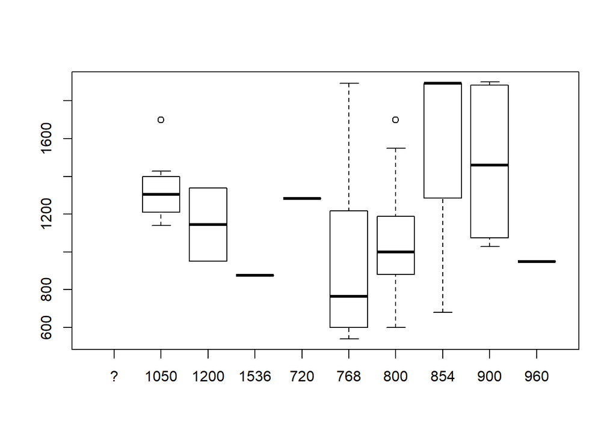

```
According to the summaries, there is no difference between 'lm_b' and 'lm_b1'.

Based on the output above, only factors 'Max.Horizontal.Resolution768' and 'Max.Horizontal.Resolution800' have a clear relationship with Price. Moreover, there is 0.5 significant level of evidence supporting that these two factors have negative relationship with Price, respectively.
```

```r
plot(laptops$Max.Horizontal.Resolution, laptops$Price)
```

```r
# c
lm_c = lm(Price ~ Manufacturer + Operating.System, data = laptops)
summary(lm_c)
```

```
##
## Call:
## lm(formula = Price ~ Manufacturer + Operating.System, data = laptops)
##
## Residuals:
##     Min      1Q  Median      3Q     Max
## -506.16 -230.37    2.21  189.54  853.84
##
## Coefficients: (1 not defined because of singularities)
##                                  Estimate Std. Error t value Pr(>|t|)
## (Intercept)                        988.32     185.35   5.332 7.02e-07 ***
## ManufacturerApple                   56.84     193.60   0.294  0.76972
## ManufacturerAsus                   647.31     245.20   2.640  0.00976 **
## ManufacturerFujitsu                572.11     221.54   2.582  0.01141 *
## ManufacturerHP_(Hewlett-Packard)    24.67     195.03   0.126  0.89962
## ManufacturerLenovo                  72.25     197.59   0.366  0.71547
## ManufacturerToshiba               -258.32     370.71  -0.697  0.48769
## Operating.SystemVista_Business         NA         NA      NA       NA
## ---
## Signif. codes:  0 '***' 0.001 '**' 0.01 '*' 0.05 '.' 0.1 ' ' 1
##
## Residual standard error: 321 on 91 degrees of freedom
## Multiple R-squared:  0.2514, Adjusted R-squared:  0.202
## F-statistic: 5.092 on 6 and 91 DF,  p-value: 0.0001508
```

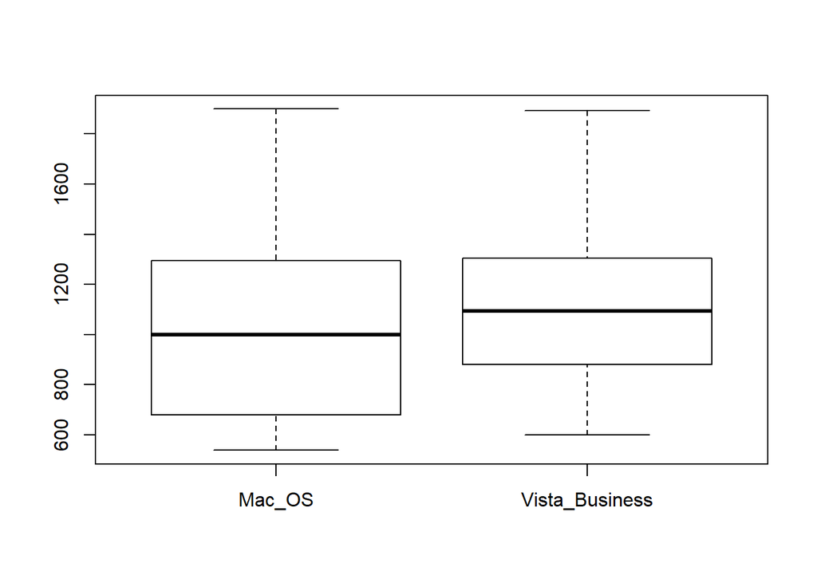

```r
plot(laptops$Operating.System, laptops$Price)
```

```r
table(laptops$Manufacturer, laptops$Operating.System)
```

```
##
##                        Mac_OS Vista_Business
##   Acer                      0              3
##   Apple                    33              0
##   Asus                      0              4
##   Fujitsu                   0              7
##   HP_(Hewlett-Packard)      0             28
##   Lenovo                    0             22
##   Toshiba                   0              1
```

[output not shown]

```r
# d
lm_d1 = lm(Price ~ Processor.Speed+Processor, data = laptops)
summary(lm_d1)
```

```
##
## Call:
## lm(formula = Price ~ Processor.Speed + Processor, data = laptops)
##
## Residuals:
##     Min      1Q  Median      3Q     Max
## -422.53 -191.31  -71.33   94.77 1188.92
##
## Coefficients:
##                           Estimate Std. Error t value Pr(>|t|)
## (Intercept)              -557.2900   314.0213  -1.775   0.0793 .
## Processor.Speed             0.6694     0.1307   5.120 1.67e-06 ***
## ProcessorAMD Turion 64x2  418.2613   246.9239   1.694   0.0937 .
## ProcessorIntel Celeron     64.2518   294.2121   0.218   0.8276
## ProcessorIntel Core2 Duo  507.8088   211.1538   2.405   0.0182 *
## ProcessorPowerPC          589.8201   226.6253   2.603   0.0108 *
## ---
## Signif. codes:  0 '***' 0.001 '**' 0.01 '*' 0.05 '.' 0.1 ' ' 1
##
## Residual standard error: 294.1 on 92 degrees of freedom
## Multiple R-squared:  0.365,  Adjusted R-squared:  0.3305
## F-statistic: 10.58 on 5 and 92 DF,  p-value: 4.826e-08
```

```r
lm_d2 = lm(Price ~ Processor.Speed*Processor, data = laptops)
summary(lm_d2)
```

```
##
## Call:
## lm(formula = Price ~ Processor.Speed * Processor, data = laptops)
##
## Residuals:
##     Min      1Q  Median      3Q     Max
## -474.45 -202.78  -39.66  105.45 1028.17
##
## Coefficients: (2 not defined because of singularities)
##                                            Estimate Std. Error t value
## (Intercept)                              -1298.8964   447.3069  -2.904
## Processor.Speed                              1.0814     0.2211   4.890
## ProcessorAMD Turion 64x2                  2808.7989  2687.0440   1.045
## ProcessorIntel Celeron                      93.0921   289.0752   0.322
## ProcessorIntel Core2 Duo                  1623.8082   536.4962   3.027
## ProcessorPowerPC                           793.8181   239.6604   3.312
## Processor.Speed:ProcessorAMD Turion 64x2    -1.4174     1.6287  -0.870
## Processor.Speed:ProcessorIntel Celeron           NA         NA      NA
## Processor.Speed:ProcessorIntel Core2 Duo    -0.6135     0.2720  -2.256
## Processor.Speed:ProcessorPowerPC                 NA         NA      NA
##                                          Pr(>|t|)
## (Intercept)                               0.00464 **
## Processor.Speed                          4.37e-06 ***
## ProcessorAMD Turion 64x2                  0.29868
## ProcessorIntel Celeron                    0.74817
## ProcessorIntel Core2 Duo                  0.00322 **
## ProcessorPowerPC                          0.00133 **
## Processor.Speed:ProcessorAMD Turion 64x2  0.38647
## Processor.Speed:ProcessorIntel Celeron         NA
## Processor.Speed:ProcessorIntel Core2 Duo  0.02649 *
## Processor.Speed:ProcessorPowerPC               NA
## ---
## Signif. codes:  0 '***' 0.001 '**' 0.01 '*' 0.05 '.' 0.1 ' ' 1
##
## Residual standard error: 288.7 on 90 degrees of freedom
## Multiple R-squared:  0.4014, Adjusted R-squared:  0.3549
## F-statistic: 8.622 on 7 and 90 DF,  p-value: 4.651e-08
```

```r
table(laptops$Processor.Speed, laptops$Processor)
```

```
##
##        AMD Mobile Sempron AMD Turion 64x2 Intel Celeron Intel Core2 Duo
##   867                   0               0             0               0
##   933                   0               0             0               0
##   1000                  0               0             0               0
##   1060                  0               0             0               2
##   1200                  0               0             0               0
##   1250                  0               0             0               0
##   1330                  0               0             0               0
##   1420                  0               0             0               0
##   1500                  0               0             0               1
##   1600                  0               4             0               3
##   1660                  0               0             0              10
##   1670                  0               0             0               0
##   1730                  0               0             2               2
```

[output cut: 29 more lines]

[output not shown]

## ANOVA for nested models

Recall that we can use ANOVA tests to compare two multiple regressions, when one model is nested in the other. This is particularly useful when the models have many factors, so it might be hard to tell which variable is more significant from the t-scores.

### Question 3:

Consider the following model:

```r
  lm_3 = lm(Price ~ Port.Replicator + Bluetooth + Manufacturer, data = laptops)
```

If you had to remove exactly one of the three variables from the model, which one would you remove? Why?

```r
lm_3.1 = lm(Price ~ Bluetooth + Manufacturer, data = laptops)
lm_3.2 = lm(Price ~ Port.Replicator + Manufacturer, data = laptops)
lm_3.3 = lm(Price ~ Port.Replicator + Bluetooth, data = laptops)
anova(lm_3.1, lm_3)
```

```
## Analysis of Variance Table
##
## Model 1: Price ~ Bluetooth + Manufacturer
## Model 2: Price ~ Port.Replicator + Bluetooth + Manufacturer
##   Res.Df     RSS Df Sum of Sq      F  Pr(>F)
## 1     90 8267880
## 2     89 7848828  1    419051 4.7517 0.03191 *
## ---
## Signif. codes:  0 '***' 0.001 '**' 0.01 '*' 0.05 '.' 0.1 ' ' 1
```

```r
anova(lm_3.2, lm_3)
```

```
## Analysis of Variance Table
##
## Model 1: Price ~ Port.Replicator + Manufacturer
## Model 2: Price ~ Port.Replicator + Bluetooth + Manufacturer
##   Res.Df     RSS Df Sum of Sq     F   Pr(>F)
## 1     90 8715023
## 2     89 7848828  1    866195 9.822 0.002336 **
## ---
## Signif. codes:  0 '***' 0.001 '**' 0.01 '*' 0.05 '.' 0.1 ' ' 1
```

```r
anova(lm_3.3, lm_3)
```

```
## Analysis of Variance Table
##
## Model 1: Price ~ Port.Replicator + Bluetooth
## Model 2: Price ~ Port.Replicator + Bluetooth + Manufacturer
##   Res.Df      RSS Df Sum of Sq      F    Pr(>F)
## 1     95 10766965
## 2     89  7848828  6   2918137 5.5149 6.797e-05 ***
## ---
## Signif. codes:  0 '***' 0.001 '**' 0.01 '*' 0.05 '.' 0.1 ' ' 1
```

[output not shown]

### Question 4:

```r
lm_O = lm(Price ~ Operating.System, data = laptops)
summary(lm_O)
```

```
##
## Call:
## lm(formula = Price ~ Operating.System, data = laptops)
##
## Residuals:
##     Min      1Q  Median      3Q     Max
## -521.87 -269.70  -31.88  214.80  853.84
##
## Coefficients:
##                                Estimate Std. Error t value Pr(>|t|)
## (Intercept)                     1045.16      62.57  16.704   <2e-16 ***
## Operating.SystemVista_Business    75.71      76.83   0.985    0.327
## ---
## Signif. codes:  0 '***' 0.001 '**' 0.01 '*' 0.05 '.' 0.1 ' ' 1
##
## Residual standard error: 359.4 on 96 degrees of freedom
## Multiple R-squared:  0.01001,    Adjusted R-squared:  -0.0002982
## F-statistic: 0.9711 on 1 and 96 DF,  p-value: 0.3269
```

```r
lm_M = lm(Price ~ Manufacturer, data = laptops)
summary(lm_M)
```

```
##
## Call:
## lm(formula = Price ~ Manufacturer, data = laptops)
##
## Residuals:
##     Min      1Q  Median      3Q     Max
## -506.16 -230.37    2.21  189.54  853.84
##
## Coefficients:
##                                  Estimate Std. Error t value Pr(>|t|)
## (Intercept)                        988.32     185.35   5.332 7.02e-07 ***
## ManufacturerApple                   56.84     193.60   0.294  0.76972
## ManufacturerAsus                   647.31     245.20   2.640  0.00976 **
## ManufacturerFujitsu                572.11     221.54   2.582  0.01141 *
## ManufacturerHP_(Hewlett-Packard)    24.67     195.03   0.126  0.89962
## ManufacturerLenovo                  72.25     197.59   0.366  0.71547
## ManufacturerToshiba               -258.32     370.71  -0.697  0.48769
## ---
## Signif. codes:  0 '***' 0.001 '**' 0.01 '*' 0.05 '.' 0.1 ' ' 1
##
## Residual standard error: 321 on 91 degrees of freedom
## Multiple R-squared:  0.2514, Adjusted R-squared:  0.202
## F-statistic: 5.092 on 6 and 91 DF,  p-value: 0.0001508
```

[output not shown]

## Collinearity

Recall from lecture that one major concern in Multiple Regression is *collinearity*, or correlation between explanatory variables. One way to measure this is through the Variance Inflation Factor. Use the code below to install an **R** package that will calculate this, as well as to get rid of the useless variables we discovered in Questions 1-4.

```r
  # Install vif package
  require("car")
  # Get rid of identified useless variables
  bad = c("Port.Replicator", "Subwoofer", "CDMA")
  lt = laptops[, !(names(laptops) %in% bad)]
```

### Question 5:

Try the following regression, and then use `vif( )` to check for collinearity. Are there any variables we should be worried about? Decide which ones to remove (if any) from `lt`.

```r
  lm_4 = lm(Price ~ .-Operating.System, data = lt)
  summary(lm_4)
```

```
##
## Call:
## lm(formula = Price ~ . - Operating.System, data = lt)
##
## Residuals:
##     Min      1Q  Median      3Q     Max
## -671.52  -56.19    0.00   70.71  442.27
##
## Coefficients:
##                                    Estimate Std. Error t value Pr(>|t|)
## (Intercept)                       -83.49162  376.55421  -0.222  0.82518
## Max.Horizontal.Resolution1200    -448.44615  183.01048  -2.450  0.01681
## Max.Horizontal.Resolution1536    -335.80512  223.82049  -1.500  0.13809
## Max.Horizontal.Resolution720     -677.73712  243.84733  -2.779  0.00701
## Max.Horizontal.Resolution768      -73.28530  109.32881  -0.670  0.50489
## Max.Horizontal.Resolution800     -245.68689   88.44525  -2.778  0.00704
## Max.Horizontal.Resolution854      657.18640  156.31506   4.204 7.72e-05
## Max.Horizontal.Resolution900      245.11481  132.56954   1.849  0.06875
## Max.Horizontal.Resolution960     -450.00000  265.10579  -1.697  0.09412
## Memory.TechnologyDDR2             498.58464  219.60360   2.270  0.02631
## Memory.TechnologySDRAM            -78.79985  196.39394  -0.401  0.68949
## Installed.Memory                    0.01463    0.08339   0.175  0.86128
## Processor.Speed                     0.27035    0.12505   2.162  0.03410
## ProcessorAMD Turion 64x2          212.77095  173.09880   1.229  0.22318
## ProcessorIntel Celeron           -218.99520  274.66117  -0.797  0.42800
## ProcessorIntel Core2 Duo          258.63307  165.95959   1.558  0.12371
## ProcessorPowerPC                  269.43801  281.45792   0.957  0.34176
## ManufacturerApple                 183.55625  142.27029   1.290  0.20129
## ManufacturerAsus                  575.39084  170.70812   3.371  0.00123
## ManufacturerFujitsu               307.97463  152.31860   2.022  0.04707
## ManufacturerHP_(Hewlett-Packard) -154.52881  129.11676  -1.197  0.23547
## ManufacturerLenovo                -83.70270  129.45617  -0.647  0.52005
## ManufacturerToshiba               152.04385  326.67710   0.465  0.64309
## InfraredYES                       108.69418   81.84590   1.328  0.18854
## BluetoothYES                      -13.74673   57.69132  -0.238  0.81237
## Docking.StationYES                114.94321   75.66085   1.519  0.13328
## FingerprintYES                    -48.27818   61.23341  -0.788  0.43315
## External.BatteryYES               265.20820  215.21863   1.232  0.22203
## Warranty.Days                       0.23478    0.10308   2.278  0.02586
##
```

[output cut: 20 more lines]

```
## ManufacturerHP_(Hewlett-Packard)
## ManufacturerLenovo
## ManufacturerToshiba
## InfraredYES
## BluetoothYES
## Docking.StationYES
## FingerprintYES
## External.BatteryYES
## Warranty.Days                    *
## ---
## Signif. codes:  0 '***' 0.001 '**' 0.01 '*' 0.05 '.' 0.1 ' ' 1
##
## Residual standard error: 187.5 on 69 degrees of freedom
## Multiple R-squared:  0.8065, Adjusted R-squared:  0.7279
## F-statistic: 10.27 on 28 and 69 DF,  p-value: 2.726e-15
```

```r
  vif(lm_4)
```

```
##                                 GVIF Df GVIF^(1/(2*Df))
## Max.Horizontal.Resolution  44.218383  8        1.267215
## Memory.Technology          22.753644  2        2.184051
## Installed.Memory            3.952615  1        1.988118
## Processor.Speed             4.523810  1        2.126925
## Processor                 120.863205  4        1.820903
## Manufacturer               70.235857  6        1.425213
## Infrared                    1.861535  1        1.364381
## Bluetooth                   2.320484  1        1.523313
## Docking.Station             3.751799  1        1.936956
## Fingerprint                 2.369198  1        1.539220
## External.Battery            1.304659  1        1.142217
## Warranty.Days               2.097500  1        1.448275
```

```
Based on the output above, the VIF of 'Max.Horizontal.Resolution', 'Memory.Technology', 'Processor' and 'Manufacturer' is much larger than 10. Therefore, 'Max.Horizontal.Resolution', 'Memory.Technology', 'Processor' and 'Manufacturer' should be removed from 'lt'.
```

### Question 6:

Compare the following regressions via `anova( )`, and look at `vif( )` for each. Make an argument for keeping either `Manufacturer` or `Operating.System` in your final regression.

```r
  lm_full = lm(Price ~ . , data = lt)
  lm_5 = lm(Price ~ .-Manufacturer, data = lt)
  lm_6 = lm(Price ~ .-Operating.System, data = lt)

  anova(lm_5, lm_full)
```

```
## Analysis of Variance Table
##
## Model 1: Price ~ (Max.Horizontal.Resolution + Memory.Technology + Installed.Memory +
##     Processor.Speed + Processor + Manufacturer + Infrared + Bluetooth +
##     Docking.Station + Fingerprint + External.Battery + Operating.System +
##     Warranty.Days) - Manufacturer
## Model 2: Price ~ Max.Horizontal.Resolution + Memory.Technology + Installed.Memory +
##     Processor.Speed + Processor + Manufacturer + Infrared + Bluetooth +
##     Docking.Station + Fingerprint + External.Battery + Operating.System +
##     Warranty.Days
##   Res.Df     RSS Df Sum of Sq      F    Pr(>F)
## 1     74 3713727
## 2     69 2424697  5   1289030 7.3364 1.456e-05 ***
## ---
## Signif. codes:  0 '***' 0.001 '**' 0.01 '*' 0.05 '.' 0.1 ' ' 1
```

```r
  anova(lm_6, lm_full)
```

```
## Analysis of Variance Table
##
## Model 1: Price ~ (Max.Horizontal.Resolution + Memory.Technology + Installed.Memory +
##     Processor.Speed + Processor + Manufacturer + Infrared + Bluetooth +
##     Docking.Station + Fingerprint + External.Battery + Operating.System +
##     Warranty.Days) - Operating.System
## Model 2: Price ~ Max.Horizontal.Resolution + Memory.Technology + Installed.Memory +
##     Processor.Speed + Processor + Manufacturer + Infrared + Bluetooth +
##     Docking.Station + Fingerprint + External.Battery + Operating.System +
##     Warranty.Days
##   Res.Df     RSS Df Sum of Sq F Pr(>F)
## 1     69 2424697
## 2     69 2424697  0         0
```

```r
  vif(lm_5)
```

```
##                                GVIF Df GVIF^(1/(2*Df))
## Max.Horizontal.Resolution 18.466246  8        1.199910
## Memory.Technology         22.139219  2        2.169155
## Installed.Memory           3.092918  1        1.758670
## Processor.Speed            4.102502  1        2.025464
## Processor                 44.834382  4        1.608612
## Infrared                   1.598262  1        1.264224
## Bluetooth                  2.185466  1        1.478332
## Docking.Station            3.100851  1        1.760923
## Fingerprint                2.132263  1        1.460227
## External.Battery           1.273896  1        1.128670
## Operating.System           4.277872  1        2.068302
## Warranty.Days              1.905359  1        1.380347
```

```r
  vif(lm_6)
```

```
##                                 GVIF Df GVIF^(1/(2*Df))
## Max.Horizontal.Resolution  44.218383  8        1.267215
## Memory.Technology          22.753644  2        2.184051
## Installed.Memory            3.952615  1        1.988118
## Processor.Speed             4.523810  1        2.126925
## Processor                 120.863205  4        1.820903
## Manufacturer               70.235857  6        1.425213
## Infrared                    1.861535  1        1.364381
## Bluetooth                   2.320484  1        1.523313
## Docking.Station             3.751799  1        1.936956
## Fingerprint                 2.369198  1        1.539220
## External.Battery            1.304659  1        1.142217
## Warranty.Days               2.097500  1        1.448275
```

[output not shown]

## Narrowing down the model

We have now established a final set of candidate variables from which to predict the price of laptops. Install the **R** package called “leaps”. This package automatically performs several types of variable selection.

```r
#install.packages("leaps")
require("leaps")
```

### Question 7

1. Look at the documentation for the function `regsubsets( )`. How many types of variable selection can be performed? What are they? Which measures of model fit does the function output? ``` The function ‘regsubsets( )’ can perform four types of variablr selection.

They are exhaustive search, forward selection, backward selection, and sequential replacement to search.

The function outputs following measures of model fit: rsq: The r-squared for each model. rss: Residual sum of squares for each model. adjr2: Adjusted r-squared. cp: Mallows’Cp. bic: Schwartz’s information criterion, BIC. ```

2. Apply `regsubsets( )` to a regression predicting `Price` from all reasonable variables, using forward selection. Plot the results by using `plot( )` on the output. Use the option `scale = "adjr2"` inside `plot( )` to change the measure of model fit to be adjusted R-squared.

```r
reg_f = regsubsets(Price ~., data = lt, method = "forward")
```

```
## Reordering variables and trying again:
```

```r
summary(reg_f)
```

```
## Subset selection object
## Call: regsubsets.formula(Price ~ ., data = lt, method = "forward")
## 30 Variables  (and intercept)
##                                  Forced in Forced out
## Max.Horizontal.Resolution1050        FALSE      FALSE
## Max.Horizontal.Resolution1200        FALSE      FALSE
## Max.Horizontal.Resolution1536        FALSE      FALSE
## Max.Horizontal.Resolution720         FALSE      FALSE
## Max.Horizontal.Resolution768         FALSE      FALSE
## Max.Horizontal.Resolution800         FALSE      FALSE
## Max.Horizontal.Resolution854         FALSE      FALSE
## Max.Horizontal.Resolution900         FALSE      FALSE
## Memory.TechnologyDDR2                FALSE      FALSE
## Memory.TechnologySDRAM               FALSE      FALSE
## Installed.Memory                     FALSE      FALSE
```

[output cut: 151 more lines]

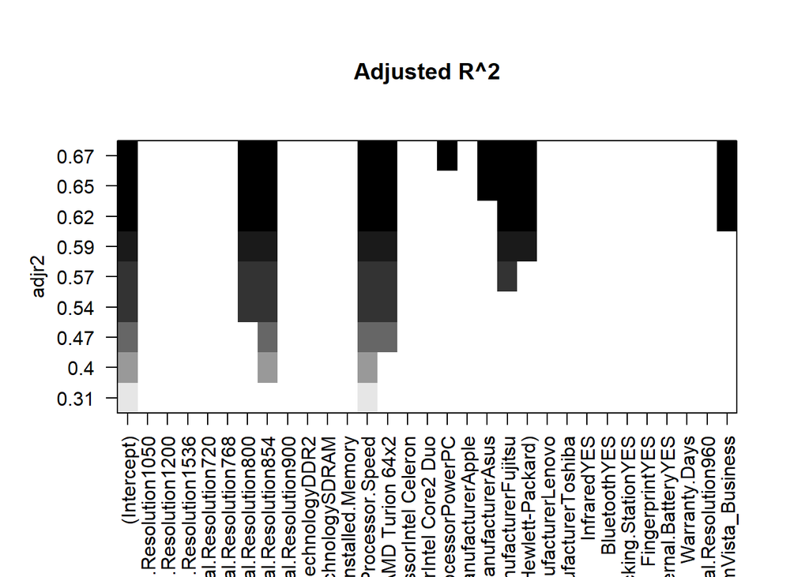

```r
plot(reg_f, scale = "adjr2",main = "Adjusted R^2")
```

```r
summary(reg_f)$adjr2
```

```
## [1] 0.3122082 0.4028581 0.4712253 0.5372524 0.5699844 0.5912673 0.6194942
## [8] 0.6514909 0.6658748
```

3. Using `regsubsets( )` to search exhaustively, and using Mallow’s Cp as the measure of model fit, what is the best model for predicting `Price`?

```r
reg_ff = regsubsets(Price ~. , data = lt, method = "exhaustive")
```

```
## Reordering variables and trying again:
```

```r
require("car")
reg_e = subsets(reg_ff, statistic="cp", legend = FALSE, main = "Mallow Cp")
```

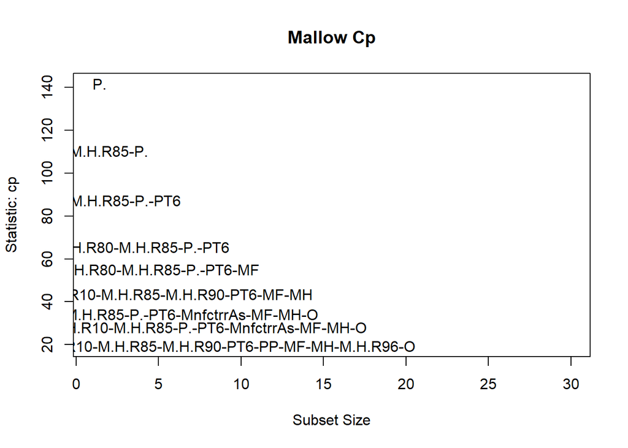

[output not shown]

### Question 8

Use your final model in 6c for the following: a. Make a plot of the predicted prices of each laptop in the dataset versus the true prices. *Hint: use `predict( )`* Is there anything we might be concerned about from these predictions?

```r
my_lm = lm(Price ~ factor(Max.Horizontal.Resolution) + Processor.Speed + factor(Processor) + factor(Manufacturer) + Operating.System, data = lt)
summary(my_lm)
```

```
##
## Call:
## lm(formula = Price ~ factor(Max.Horizontal.Resolution) + Processor.Speed +
##     factor(Processor) + factor(Manufacturer) + Operating.System,
##     data = lt)
##
## Residuals:
##     Min      1Q  Median      3Q     Max
## -592.98 -104.56   -6.14   97.24  673.79
##
## Coefficients: (1 not defined because of singularities)
##                                           Estimate Std. Error t value
## (Intercept)                               242.2975   310.7326   0.780
## factor(Max.Horizontal.Resolution)1200    -421.8524   184.0745  -2.292
## factor(Max.Horizontal.Resolution)1536    -299.9385   232.5814  -1.290
## factor(Max.Horizontal.Resolution)720     -769.8399   256.7783  -2.998
## factor(Max.Horizontal.Resolution)768     -146.7365   107.8124  -1.361
## factor(Max.Horizontal.Resolution)800     -302.0809    80.8699  -3.735
## factor(Max.Horizontal.Resolution)854      533.9971   160.9473   3.318
## factor(Max.Horizontal.Resolution)900      121.5901   124.0634   0.980
## factor(Max.Horizontal.Resolution)960     -113.8748   235.1419  -0.484
## Processor.Speed                             0.4046     0.1166   3.471
## factor(Processor)AMD Turion 64x2          264.6814   177.7308   1.489
## factor(Processor)Intel Celeron           -154.2513   272.3204  -0.566
## factor(Processor)Intel Core2 Duo          367.0193   155.5345   2.360
## factor(Processor)PowerPC                   22.7218   205.9531   0.110
## factor(Manufacturer)Apple                 122.1695   145.2192   0.841
## factor(Manufacturer)Asus                  633.3082   180.4653   3.509
## factor(Manufacturer)Fujitsu               379.8293   159.8023   2.377
## factor(Manufacturer)HP_(Hewlett-Packard)  -20.9010   130.0282  -0.161
## factor(Manufacturer)Lenovo                -41.2819   133.1069  -0.310
## factor(Manufacturer)Toshiba               244.0725   329.5664   0.741
## Operating.SystemVista_Business                  NA         NA      NA
##                                          Pr(>|t|)
## (Intercept)                              0.437891
## factor(Max.Horizontal.Resolution)1200    0.024618 *
## factor(Max.Horizontal.Resolution)1536    0.200998
## factor(Max.Horizontal.Resolution)720     0.003644 **
## factor(Max.Horizontal.Resolution)768     0.177422
## factor(Max.Horizontal.Resolution)800     0.000355 ***
## factor(Max.Horizontal.Resolution)854     0.001380 **
## factor(Max.Horizontal.Resolution)900     0.330085
## factor(Max.Horizontal.Resolution)960     0.629543
## Processor.Speed                          0.000849 ***
## factor(Processor)AMD Turion 64x2         0.140460
## factor(Processor)Intel Celeron           0.572726
## factor(Processor)Intel Core2 Duo         0.020789 *
## factor(Processor)PowerPC                 0.912435
## factor(Manufacturer)Apple                0.402765
## factor(Manufacturer)Asus                 0.000749 ***
## factor(Manufacturer)Fujitsu              0.019911 *
## factor(Manufacturer)HP_(Hewlett-Packard) 0.872712
## factor(Manufacturer)Lenovo               0.757281
## factor(Manufacturer)Toshiba              0.461168
## Operating.SystemVista_Business                 NA
## ---
## Signif. codes:  0 '***' 0.001 '**' 0.01 '*' 0.05 '.' 0.1 ' ' 1
##
## Residual standard error: 209.4 on 78 degrees of freedom
## Multiple R-squared:  0.7269, Adjusted R-squared:  0.6604
## F-statistic: 10.93 on 19 and 78 DF,  p-value: 5.49e-15
```

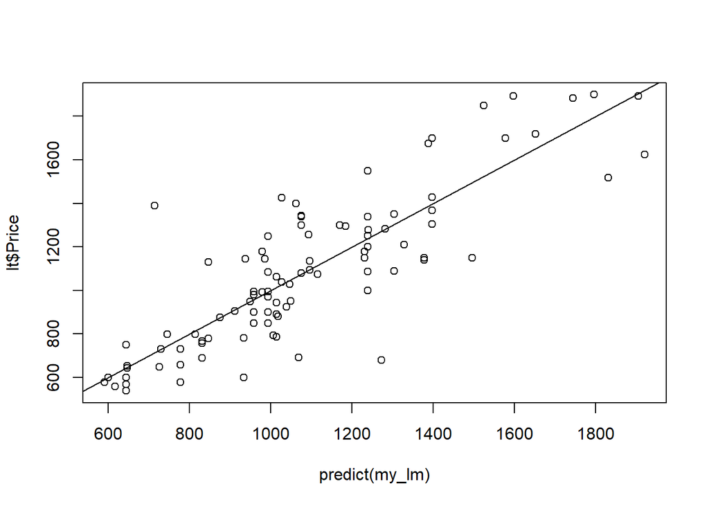

```
According to the output above, there are several outliers.
```

```r
plot(predict(my_lm),lt$Price)
abline(0,1)
```

2. Look at some diagnostic plots and/or measurements for your final model, and comment on them.

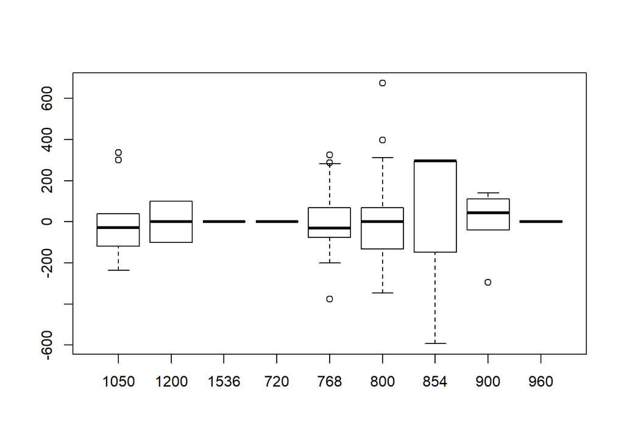

```r
res <- resid(my_lm)
plot(factor(lt$Max.Horizontal.Resolution), res)
```

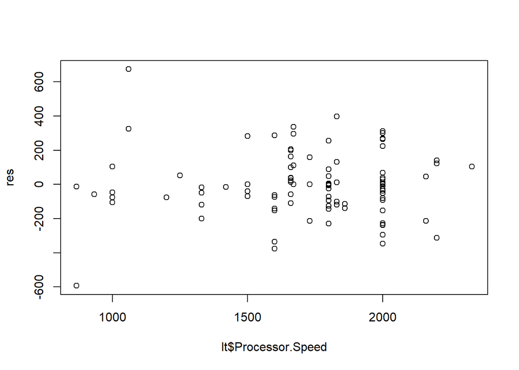

```r
plot(lt$Processor.Speed, res)
```

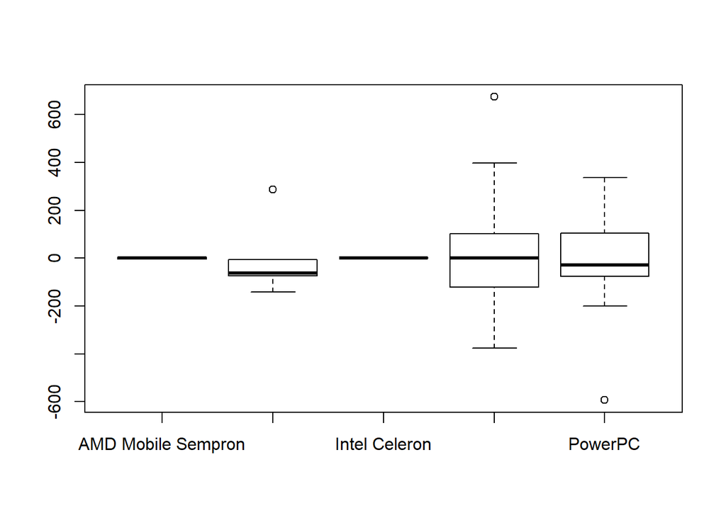

```r
plot(factor(lt$Processor), res)
```

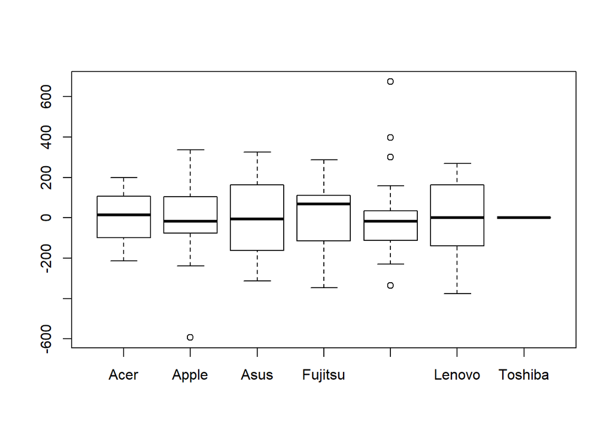

```r
plot(factor(lt$Manufacturer), res)
```

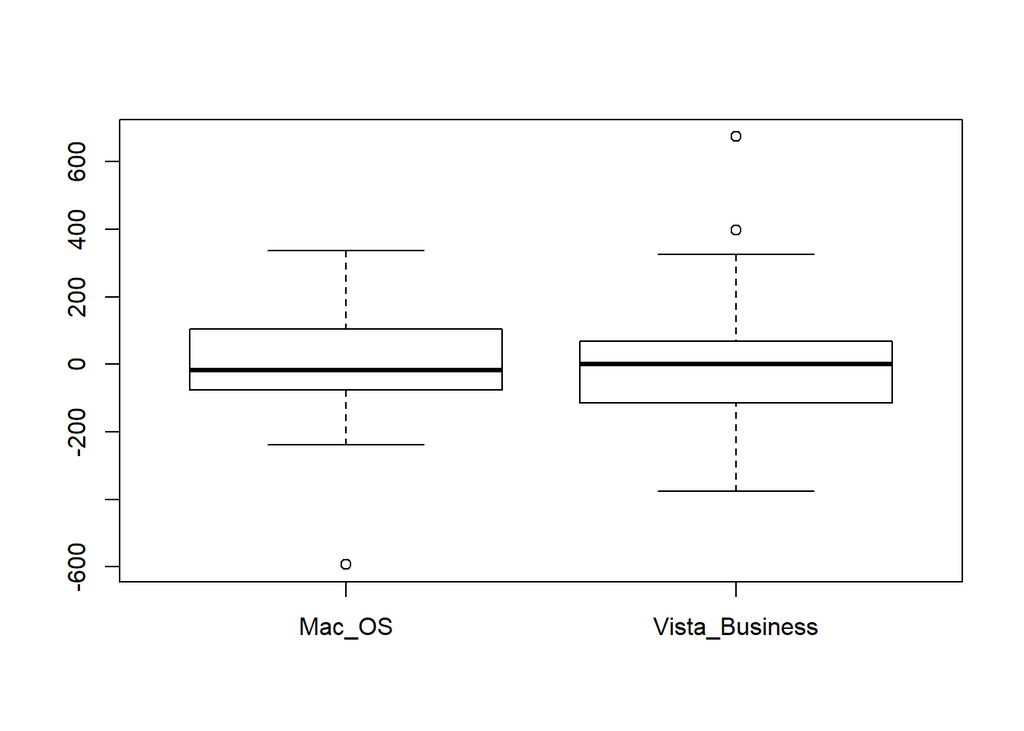

```r
plot(lt$Operating.System, res)
```

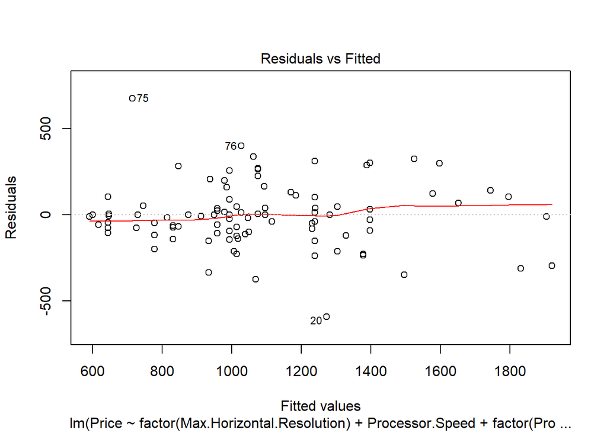

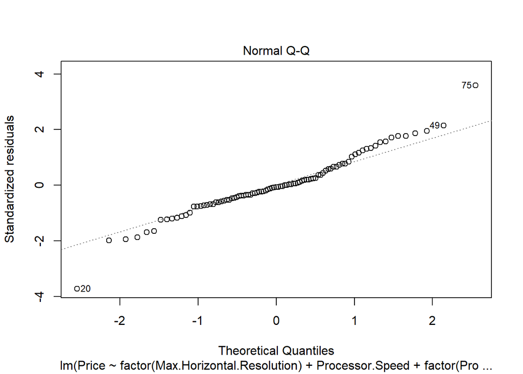

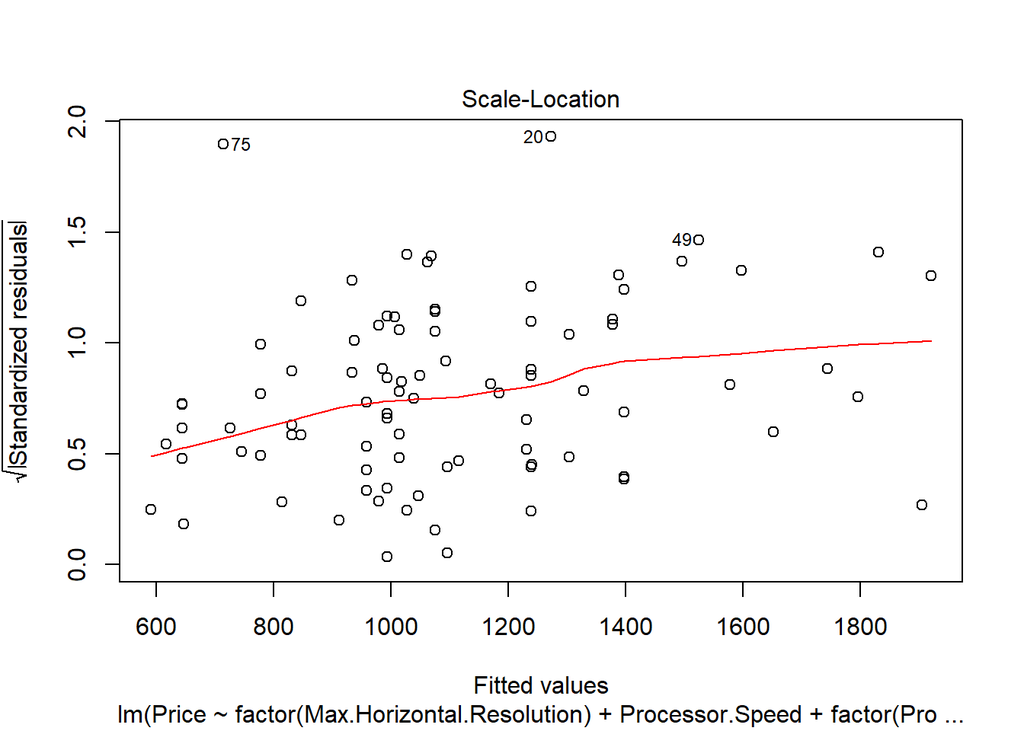

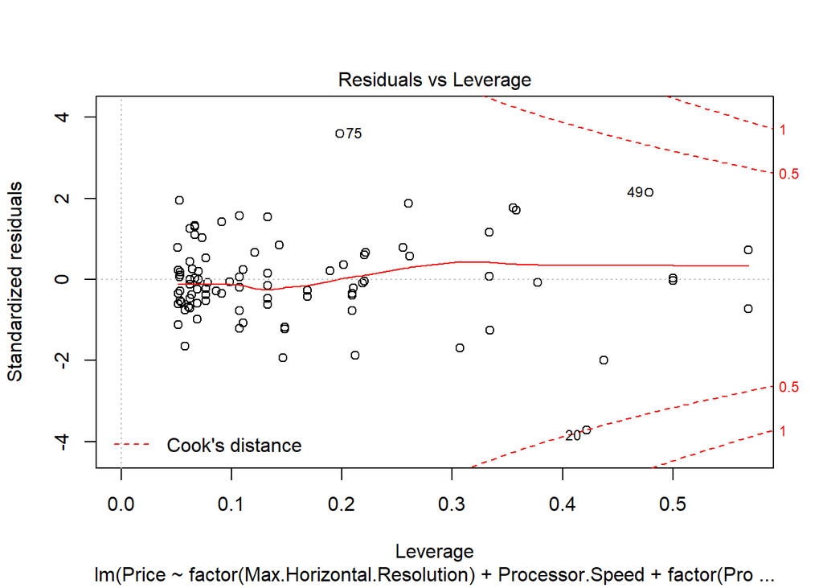

[output not shown]

```r
plot(my_lm)
```

## Your Turn

Suppose you are consulting in marketing. One of your clients, Cooper, says “Customers treat all PC manufacturers the same. People only pay more for some brands because those laptops happen to include better features.” Another client, Tina, says “No, customers have a preference for specific manufacturers, and they will pay more for these brands even if the laptops are otherwise identical.”

Based on this dataset, who do you think is right, Cooper or Tina? Do you believe price differences in PCs are only due to different features, or is there a manufacturer effect as well? Be creative in your answer; go beyond your response to Question 5. Make sure to support your argument with plots and clear explanations.

*Note: A “PC” in this case refers any laptop that is not made by Apple.*

```r
First = lm(Price ~ factor(Max.Horizontal.Resolution) + Processor.Speed + factor(Processor) + Operating.System, data = lt)
summary(First)
```

```
##
## Call:
## lm(formula = Price ~ factor(Max.Horizontal.Resolution) + Processor.Speed +
##     factor(Processor) + Operating.System, data = lt)
##
## Residuals:
##     Min      1Q  Median      3Q     Max
## -602.05 -121.10  -30.94  117.23  825.08
##
## Coefficients:
##                                        Estimate Std. Error t value
## (Intercept)                             29.0812   359.7571   0.081
## factor(Max.Horizontal.Resolution)1200 -159.1194   202.9854  -0.784
## factor(Max.Horizontal.Resolution)1536 -290.8867   268.3816  -1.084
## factor(Max.Horizontal.Resolution)720  -134.9515   261.4116  -0.516
## factor(Max.Horizontal.Resolution)768    78.9492   110.0407   0.717
## factor(Max.Horizontal.Resolution)800  -255.8568    94.3282  -2.712
## factor(Max.Horizontal.Resolution)854   726.0772   183.0441   3.967
## factor(Max.Horizontal.Resolution)900   299.2662   139.4226   2.146
## factor(Max.Horizontal.Resolution)960    52.1058   274.7792   0.190
## Processor.Speed                          0.5021     0.1303   3.855
## factor(Processor)AMD Turion 64x2       324.5363   208.8690   1.554
## factor(Processor)Intel Celeron        -114.8603   251.1362  -0.457
## factor(Processor)Intel Core2 Duo       413.0628   179.7192   2.298
## factor(Processor)PowerPC                29.2899   239.2606   0.122
## Operating.SystemVista_Business         -29.4217    90.6286  -0.325
##                                       Pr(>|t|)
## (Intercept)                           0.935767
## factor(Max.Horizontal.Resolution)1200 0.435333
## factor(Max.Horizontal.Resolution)1536 0.281568
## factor(Max.Horizontal.Resolution)720  0.607059
## factor(Max.Horizontal.Resolution)768  0.475108
## factor(Max.Horizontal.Resolution)800  0.008119 **
## factor(Max.Horizontal.Resolution)854  0.000154 ***
## factor(Max.Horizontal.Resolution)900  0.034755 *
## factor(Max.Horizontal.Resolution)960  0.850064
## Processor.Speed                       0.000228 ***
## factor(Processor)AMD Turion 64x2      0.124042
## factor(Processor)Intel Celeron        0.648605
## factor(Processor)Intel Core2 Duo      0.024055 *
## factor(Processor)PowerPC              0.902863
## Operating.SystemVista_Business        0.746270
## ---
## Signif. codes:  0 '***' 0.001 '**' 0.01 '*' 0.05 '.' 0.1 ' ' 1
##
## Residual standard error: 247.8 on 83 degrees of freedom
## Multiple R-squared:  0.5932, Adjusted R-squared:  0.5246
## F-statistic: 8.646 on 14 and 83 DF,  p-value: 3.392e-11
```

```r
Second = lm(Price ~ factor(Manufacturer), data = lt)
summary(Second)
```

```
##
## Call:
## lm(formula = Price ~ factor(Manufacturer), data = lt)
##
## Residuals:
##     Min      1Q  Median      3Q     Max
## -506.16 -230.37    2.21  189.54  853.84
##
## Coefficients:
##                                          Estimate Std. Error t value
## (Intercept)                                988.32     185.35   5.332
## factor(Manufacturer)Apple                   56.84     193.60   0.294
## factor(Manufacturer)Asus                   647.31     245.20   2.640
## factor(Manufacturer)Fujitsu                572.11     221.54   2.582
## factor(Manufacturer)HP_(Hewlett-Packard)    24.67     195.03   0.126
## factor(Manufacturer)Lenovo                  72.25     197.59   0.366
## factor(Manufacturer)Toshiba               -258.32     370.71  -0.697
##                                          Pr(>|t|)
## (Intercept)                              7.02e-07 ***
## factor(Manufacturer)Apple                 0.76972
## factor(Manufacturer)Asus                  0.00976 **
## factor(Manufacturer)Fujitsu               0.01141 *
## factor(Manufacturer)HP_(Hewlett-Packard)  0.89962
## factor(Manufacturer)Lenovo                0.71547
## factor(Manufacturer)Toshiba               0.48769
## ---
## Signif. codes:  0 '***' 0.001 '**' 0.01 '*' 0.05 '.' 0.1 ' ' 1
##
## Residual standard error: 321 on 91 degrees of freedom
## Multiple R-squared:  0.2514, Adjusted R-squared:  0.202
## F-statistic: 5.092 on 6 and 91 DF,  p-value: 0.0001508
```

```r
Third = lm(Price ~  (Max.Horizontal.Resolution + Processor.Speed + Processor + Operating.System) : Manufacturer, data = lt)
summary(Third)
```

```
##
## Call:
## lm(formula = Price ~ (Max.Horizontal.Resolution + Processor.Speed +
##     Processor + Operating.System):Manufacturer, data = lt)
##
## Residuals:
##     Min      1Q  Median      3Q     Max
## -401.96  -84.16    0.00   60.29  432.18
##
## Coefficients: (73 not defined because of singularities)
##                                                                   Estimate
## (Intercept)                                                      7.300e+02
## Max.Horizontal.Resolution1050:ManufacturerAcer                          NA
## Max.Horizontal.Resolution1200:ManufacturerAcer                          NA
## Max.Horizontal.Resolution1536:ManufacturerAcer                          NA
## Max.Horizontal.Resolution720:ManufacturerAcer                           NA
## Max.Horizontal.Resolution768:ManufacturerAcer                           NA
## Max.Horizontal.Resolution800:ManufacturerAcer                    7.268e+03
## Max.Horizontal.Resolution854:ManufacturerAcer                           NA
## Max.Horizontal.Resolution900:ManufacturerAcer                           NA
## Max.Horizontal.Resolution960:ManufacturerAcer                           NA
## Max.Horizontal.Resolution1050:ManufacturerApple                 -7.128e+02
## Max.Horizontal.Resolution1200:ManufacturerApple                 -1.420e+03
## Max.Horizontal.Resolution1536:ManufacturerApple                         NA
## Max.Horizontal.Resolution720:ManufacturerApple                          NA
## Max.Horizontal.Resolution768:ManufacturerApple                  -1.020e+03
## Max.Horizontal.Resolution800:ManufacturerApple                  -1.298e+03
## Max.Horizontal.Resolution854:ManufacturerApple                  -4.018e+02
## Max.Horizontal.Resolution900:ManufacturerApple                  -8.382e+02
## Max.Horizontal.Resolution960:ManufacturerApple                  -1.163e+03
## Max.Horizontal.Resolution1050:ManufacturerAsus                          NA
## Max.Horizontal.Resolution1200:ManufacturerAsus                          NA
## Max.Horizontal.Resolution1536:ManufacturerAsus                          NA
## Max.Horizontal.Resolution720:ManufacturerAsus                    4.579e+02
## Max.Horizontal.Resolution768:ManufacturerAsus                    1.069e+03
## Max.Horizontal.Resolution800:ManufacturerAsus                    6.848e+02
## Max.Horizontal.Resolution854:ManufacturerAsus                           NA
## Max.Horizontal.Resolution900:ManufacturerAsus                           NA
## Max.Horizontal.Resolution960:ManufacturerAsus                           NA
## Max.Horizontal.Resolution1050:ManufacturerFujitsu                       NA
```

[output cut: 496 more lines]

```
## ProcessorIntel Core2 Duo:ManufacturerToshiba
## ProcessorPowerPC:ManufacturerToshiba
## Operating.SystemVista_Business:ManufacturerAcer
## Operating.SystemVista_Business:ManufacturerApple
## Operating.SystemVista_Business:ManufacturerAsus
## Operating.SystemVista_Business:ManufacturerFujitsu
## Operating.SystemVista_Business:ManufacturerHP_(Hewlett-Packard)
## Operating.SystemVista_Business:ManufacturerLenovo
## Operating.SystemVista_Business:ManufacturerToshiba
## ---
## Signif. codes:  0 '***' 0.001 '**' 0.01 '*' 0.05 '.' 0.1 ' ' 1
##
## Residual standard error: 181.3 on 65 degrees of freedom
## Multiple R-squared:  0.8295, Adjusted R-squared:  0.7456
## F-statistic: 9.884 on 32 and 65 DF,  p-value: 6.466e-15
```

[output not shown]